# Students Performance in Exams

# Minor Project (ML-July-B2)

| Columns | Column Details |
| --- | --- |
| Gender | Gender of the student |
| Race/ethnicity | Race of the Student As Group A/B/C |
| Parental level of education | What is the education Qualification of Students Parent |
| Lunch | Whether the lunch is Standard type/Free lunch or Some discounted lunch |
| Test preparation course | Whether Student has Taken or not and Completed |
| Math score | Scores in Maths |
| Reading score | Scores in Reading |
| Writing score | Scores in Writing |

## Objective of this Analysis:

To understand the how the student's performance (test scores) is affected by the other variables (Gender, Ethnicity, Parental level of education, Lunch, Test preparation course).

### What to do in Exploratory Data Analysis:

1.To Analyse insights in the dataset.\ 2.To understand the connection between the variables and to uncover the underlying structure\ 3.To extract the important Variables.\ 4.To test the underlying assumptions.\ 5.Provide Insights with Suitable Graphs and Visualizations.\ 6.Write all your inferences with supporting Analysis and Visualizations.

## Let's import the required Libraries

```python
import pandas as pd
import numpy as np
import matplotlib.pyplot as plt
%matplotlib inline
import seaborn as sns
```

*Importing Dataset*\ (Reading the data set)

```python
df = pd.read_csv('StudentsPerformance.csv')
df.head()
```

|  | gender | race/ethnicity | parental level of education | lunch | test preparation course | math score | reading score | writing score |
| --- | --- | --- | --- | --- | --- | --- | --- | --- |
| 0 | female | group B | bachelor's degree | standard | none | 72 | 72 | 74 |
| 1 | female | group C | some college | standard | completed | 69 | 90 | 88 |
| 2 | female | group B | master's degree | standard | none | 90 | 95 | 93 |
| 3 | male | group A | associate's degree | free/reduced | none | 47 | 57 | 44 |
| 4 | male | group C | some college | standard | none | 76 | 78 | 75 |

### Number of Rows and Columns

```python
df.shape
```

```
(1000, 8)
```

*This tells there are 1000 rows and 8 columns*

### Let us check if the data has some missing values.

```python
df.isnull().sum()
```

```
gender                         0
race/ethnicity                 0
parental level of education    0
lunch                          0
test preparation course        0
math score                     0
reading score                  0
writing score                  0
dtype: int64
```

*So there are no missing values in the dataset.*

### Let us check the datatype of all the column values.

```python
df.dtypes
```

```
gender                         object
race/ethnicity                 object
parental level of education    object
lunch                          object
test preparation course        object
math score                      int64
reading score                   int64
writing score                   int64
dtype: object
```

**Let us analyze the values of the columns and check whether they are numerical or categorical.**

```python
df['gender'].value_counts()
```

```
female    518
male      482
Name: gender, dtype: int64
```

```python
df['parental level of education'].value_counts()
```

```
some college          226
associate's degree    222
high school           196
some high school      179
bachelor's degree     118
master's degree        59
Name: parental level of education, dtype: int64
```

```python
df['race/ethnicity'].value_counts()
```

```
group C    319
group D    262
group B    190
group E    140
group A     89
Name: race/ethnicity, dtype: int64
```

```python
df['lunch'].value_counts()
```

```
standard        645
free/reduced    355
Name: lunch, dtype: int64
```

```python
df['test preparation course'].value_counts()
```

```
none         642
completed    358
Name: test preparation course, dtype: int64
```

From the above we understand that column, \ **“gender”, \ “parental level of education”,\ “race/ethnicity”, \ “lunch”, \ “test preparation course”**\ all are categorical variables.

And as we know marks are always numerical in category, therefore the columns, \ **“math score”, \ “read score”, \ “write score”**\ contain numerical values and hence are numerical variables.

### Lets see what our data describe

```python
df.describe()
```

|  | math score | reading score | writing score |
| --- | --- | --- | --- |
| count | 1000.00000 | 1000.000000 | 1000.000000 |
| mean | 66.08900 | 69.169000 | 68.054000 |
| std | 15.16308 | 14.600192 | 15.195657 |
| min | 0.00000 | 17.000000 | 10.000000 |
| 25% | 57.00000 | 59.000000 | 57.750000 |
| 50% | 66.00000 | 70.000000 | 69.000000 |
| 75% | 77.00000 | 79.000000 | 79.000000 |
| max | 100.00000 | 100.000000 | 100.000000 |

Here we can see the descriptive statistics of numerical variables **Math score, Reading score and Writing score**\ [such as total count, mean, standard deviation, minimum and maximum values and three quantiles of the data (25%,50%,75%)].

```python
df.describe(include = 'all')
```

|  | gender | race/ethnicity | parental level of education | lunch | test preparation course | math score | reading score | writing score |
| --- | --- | --- | --- | --- | --- | --- | --- | --- |
| count | 1000 | 1000 | 1000 | 1000 | 1000 | 1000.00000 | 1000.000000 | 1000.000000 |
| unique | 2 | 5 | 6 | 2 | 2 | NaN | NaN | NaN |
| top | female | group C | some college | standard | none | NaN | NaN | NaN |
| freq | 518 | 319 | 226 | 645 | 642 | NaN | NaN | NaN |
| mean | NaN | NaN | NaN | NaN | NaN | 66.08900 | 69.169000 | 68.054000 |
| std | NaN | NaN | NaN | NaN | NaN | 15.16308 | 14.600192 | 15.195657 |
| min | NaN | NaN | NaN | NaN | NaN | 0.00000 | 17.000000 | 10.000000 |
| 25% | NaN | NaN | NaN | NaN | NaN | 57.00000 | 59.000000 | 57.750000 |
| 50% | NaN | NaN | NaN | NaN | NaN | 66.00000 | 70.000000 | 69.000000 |
| 75% | NaN | NaN | NaN | NaN | NaN | 77.00000 | 79.000000 | 79.000000 |
| max | NaN | NaN | NaN | NaN | NaN | 100.00000 | 100.000000 | 100.000000 |

Here we can see some more information about categorical variables\ **Gender, Race/ethnicity, Parental level of education, Lunch and Test preparation course**\ [such as number of *unique* values, maxi. occuring value(*top*), its *frequancy*]

### Lets add some more columns for further calculations

```python
df['average'] = (df['math score'] + df['reading score'] + df['writing score']) /3

# df['total'] = df['math score'] + df['reading score'] + df['writing score']
# df['average'] = df['total'] / 3
```

## Distribution graphs for [ Maths, Reading, Writing and Average]

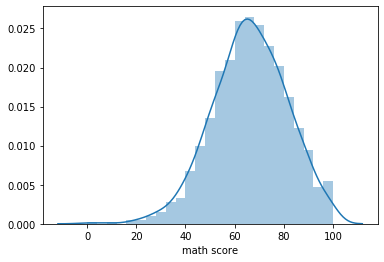

```python
sns.distplot(df['math score'])
```

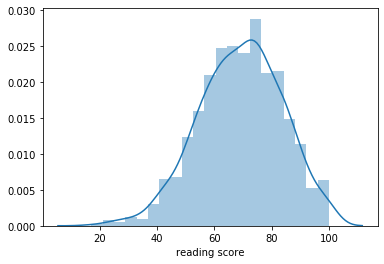

```python
sns.distplot(df['reading score'])
```

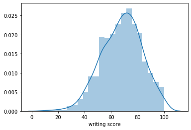

```python
sns.distplot(df['writing score'])
```

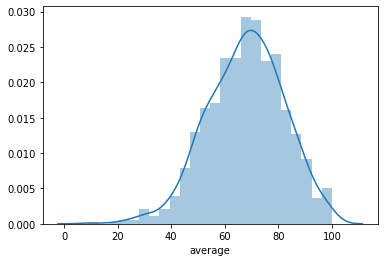

```python
sns.distplot(df['average'])
```

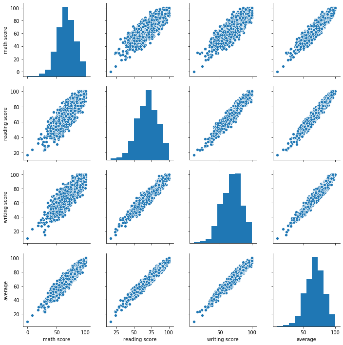

```python
sns.pairplot(df)
```

The above plots are Paired-plots, these graphs are ploted w.r.t. each other(only numeric variables)\

## Analyze average scores on the basis of categorical variables

**[ Gender, Race/Ethnicity, Parental Level of Education, Test Preparation Course” ]**

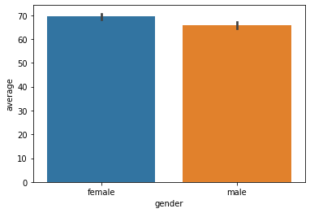

```python
sns.barplot(df['gender'], df['average'])
```

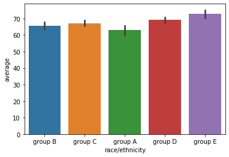

```python
sns.barplot(df['race/ethnicity'], df['average'])
```

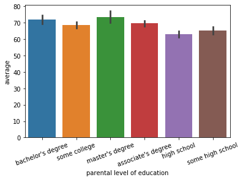

```python
sns.barplot(df['parental level of education'], df['average'])
plt.xticks(rotation=20)
```

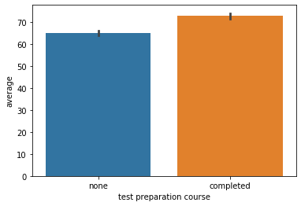

```python
sns.barplot(df['test preparation course'], df['average'])
```

### Let us the analyze the data on the basis of the no. of students [Failed / Passed in exam].

```python
df['math_PassStatus'] = np.where(df['math score']<40, 'Fail', 'Pass')
df['read_PassStatus'] = np.where(df['reading score']<40, 'Fail', 'Pass')
df['write_PassStatus'] = np.where(df['writing score']<40, 'Fail', 'Pass')
```

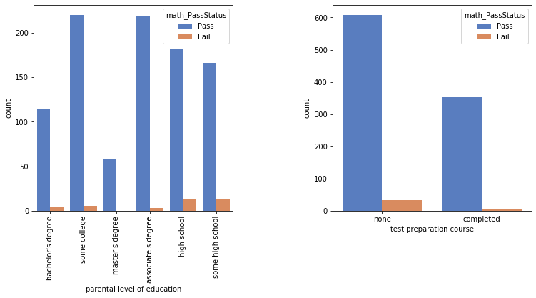

```python
plt.figure(figsize=(20,5))
plt.subplots_adjust(left=0.125, bottom=0.1, right=0.9, top=0.9,
                      wspace=0.5, hspace=0.2)
plt.subplot(131)
sns.countplot(x='parental level of education', data = df, hue='math_PassStatus',palette = 'muted')
plt.xticks(rotation='vertical')
plt.subplot(132)
sns.countplot(x='test preparation course', data = df, hue='math_PassStatus',palette = 'muted')
plt.show()

# fig, ax =plt.subplots(1,2)
# p = sns.countplot(x='parental level of education', data = df, hue='math_PassStatus',palette = 'muted',ax=ax[0])
# _ = plt.setp(p.get_xticklabels(), rotation=90)
# p = sns.countplot(x='test preparation course', data = df, hue='math_PassStatus',palette = 'muted',ax=ax[1])
# fig.show()
```

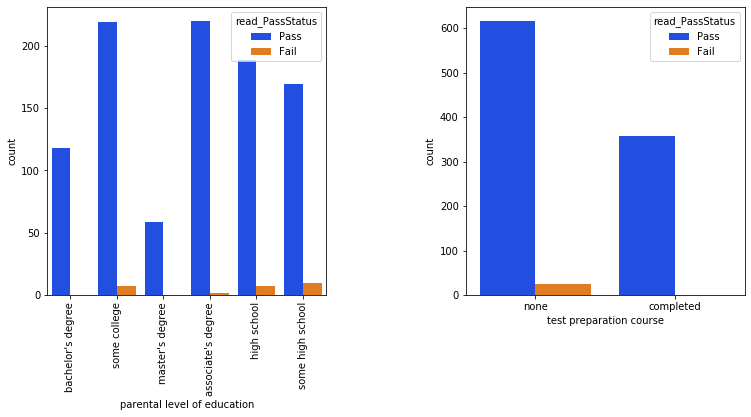

```python
plt.figure(figsize=(20,5))
plt.subplots_adjust(left=0.125, bottom=0.1, right=0.9, top=0.9,
                      wspace=0.5, hspace=0.2)
plt.subplot(131)
sns.countplot(x='parental level of education', data = df, hue='read_PassStatus',palette = 'bright')
plt.xticks(rotation='vertical')
plt.subplot(132)
sns.countplot(x='test preparation course', data = df, hue='read_PassStatus',palette = 'bright')
plt.show()

# fig, ax =plt.subplots(1,2)
# p1 = sns.countplot(x='parental level of education', data = df, hue='read_PassStatus', palette='bright', ax=ax[0])
# _ = plt.setp(p1.get_xticklabels(), rotation=90)
# p1 = sns.countplot(x='test preparation course', data = df, hue='read_PassStatus', palette='bright',ax=ax[1])
# fig.show()
```

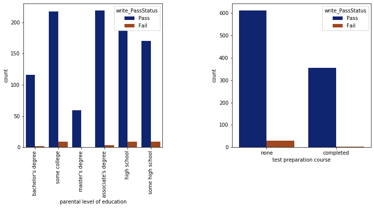

```python
plt.figure(figsize=(20,5))
plt.subplots_adjust(left=0.125, bottom=0.1, right=0.9, top=0.9,
                      wspace=0.5, hspace=0.2)
plt.subplot(131)
sns.countplot(x='parental level of education', data = df, hue='write_PassStatus', palette='dark')
plt.xticks(rotation='vertical')
plt.subplot(132)
sns.countplot(x='test preparation course', data = df, hue='write_PassStatus',palette = 'dark')
plt.show()

# fig, ax =plt.subplots(1,2)
# p1 = sns.countplot(x='parental level of education', data = df, hue='write_PassStatus', palette='dark', ax=ax[0])
# _ = plt.setp(p1.get_xticklabels(), rotation=90)
# p1 = sns.countplot(x='test preparation course', data = df, hue='write_PassStatus', palette='dark',ax=ax[1])
# fig.show()
```